# Case 2_Data Analysis Skill Test - 4intelligence

Paulo Eduardo Braga

01/12/2020

# **Objetivo**

A partir de uma base de dados de exportações e importações brasileiras serão feitas algumas análises para comércio internacional brasileiro.

## Importando arquivo `Data_Comexstat`

```r
data = read.csv('data_comexstat.csv', header = T)
```

## Análise descritiva do danco de dados

```r
skim(data)
```

Data summary

| Name | data |
| --- | --- |
| Number of rows | 117965 |
| Number of columns | 8 |
| _______________________ |  |
| Column type frequency: |  |
| character | 6 |
| numeric | 2 |
| ________________________ |  |
| Group variables | None |

**Variable type: character**

| skim_variable | n_missing | complete_rate | min | max | empty | n_unique | whitespace |
| --- | --- | --- | --- | --- | --- | --- | --- |
| date | 0 | 1 | 10 | 10 | 0 | 276 | 0 |
| product | 0 | 1 | 4 | 12 | 0 | 6 | 0 |
| state | 0 | 1 | 2 | 2 | 0 | 27 | 0 |
| country | 0 | 1 | 4 | 32 | 0 | 212 | 0 |
| type | 0 | 1 | 6 | 6 | 0 | 2 | 0 |
| route | 0 | 1 | 3 | 6 | 0 | 5 | 0 |

**Variable type: numeric**

| skim_variable | n_missing | complete_rate | mean | sd | p0 | p25 | p50 | p75 | p100 | hist |
| --- | --- | --- | --- | --- | --- | --- | --- | --- | --- | --- |
| tons | 0 | 1 | 14536.81 | 49779.26 | 0 | 124.9 | 2000 | 13534.03 | 1798446 | ▇▁▁▁▁ |
| usd | 0 | 1 | 4813150.34 | 19494115.59 | 0 | 71552.0 | 725000 | 3895943.00 | 903930411 | ▇▁▁▁▁ |

Nesse banco de dados há informações de exportações e importações realizados pelo Brasil, distinguindo entre os modais, produto, estado que importou/exportou, país de origem/destinatário, quantidade(ton) e valor (USD). Com informações mensais que vão de janeiro/1997 a dezembro/2019, há um total de 117.965 observações e não há observações faltantes (missing).

A distribuição das observações, de acordo com a modal utilizado é:

```r
summary(as.factor(data$route))
```

```
##    Air Ground  Other  River    Sea
##   2918  13038   6374   1765  93870
```

Os tipos de produtos comercilizados, foram:

```r
summary(as.factor(data$product))
```

```
##         corn soybean_meal  soybean_oil     soybeans        sugar        wheat
##        21872        18215        16116        22914        35202         3646
```

Quando considerado o modal mais utilizado para realizar o comércio internacional, o transporte marítimo representa 79,574% do total de transações realizadas, e em segundo lugar é o transporte terrestre representando 11,05% do total de transações.

Considerando a quantidade de transaçãos, o produto que lidera o ranking com a maior quantidade de transações é o `açúcar`, ele representa 29,84% do total de transações realizadas. Em seguno lugar está o `grão de soja` e em terceiro o `milho`, representanto 19,4% e 18,5% do total de transações, respectivamente.

## Item 1 - Mostrar a evolução das exportações totais mensais e anuais do Brasil (todos os estados e para todos os lugares) de ‘soja’, ‘óleo de soja’ e ‘farelo de soja’.

#### Análise do Valor exportado (dólares)

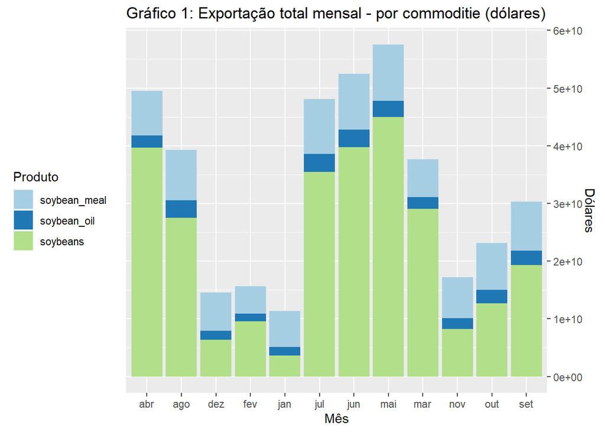

```r
#Construindo um subconjunto com os produtos selecionados
q1 <- subset(data, type == 'Export' & product %in% c('soybeans','soybean_oil','soybean_meal')) %>%
      select(c(date,product, usd)) %>%
      group_by(product , months(as.Date(date), abbreviate = T))  %>%
      summarise_at('usd', sum, na.rm = F)

# Renomeando as colunas
colnames(q1) <- c('Produto', 'Mês','Dólares')

graf_1 <- ggplot(data = q1 , aes(x = Mês, y = Dólares, fill = Produto)) + geom_bar(stat = 'identity', na.rm = T) +
      labs(title = "Gráfico 1: Exportação total mensal - por commoditie (dólares)") +
      scale_fill_brewer(palette = "Paired") +
      theme(legend.position="left") +
      scale_y_continuous(breaks = seq(0, 100000000000, 10000000000), position = "right")

graf_1
```

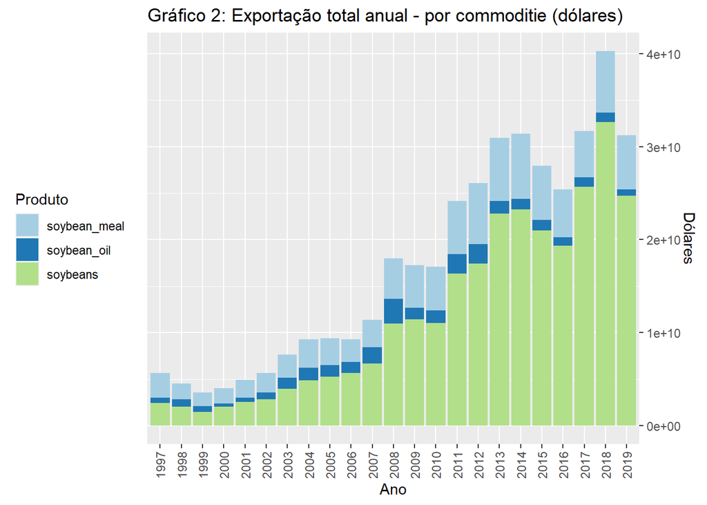

```r
#Construindo um subconjunto com os produtos selecionados
s2 <- subset(data, type == 'Export' & product %in% c('soybeans','soybean_oil','soybean_meal')) %>%
      select(c(date,product, usd)) %>%
      group_by(product , format(as.Date(date), '%Y'))  %>%
      summarise_at('usd', sum, na.rm = F)

# Renomeando as colunas
colnames(s2) <- c('Produto', 'Ano','Dólares')

graf_2 <- ggplot(data = s2 , aes(x = Ano, y = Dólares, fill = Produto)) + geom_bar(stat = 'identity', na.rm = T) +
      labs(title = "Gráfico 2: Exportação total anual - por commoditie (dólares)") +
      scale_fill_brewer(palette = "Paired") +
      theme(legend.position="left") +
      scale_y_continuous(breaks = seq(0, 100000000000, 10000000000), position = "right" ) +
      theme(axis.text.x = element_text(angle = 90, vjust = 0.5))

graf_2
```

#### Análise da quantidade exportada (tonelada)

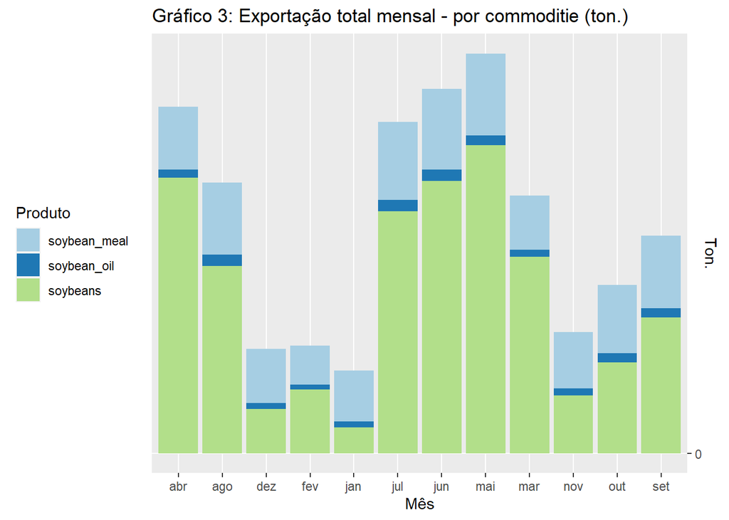

```r
#Construindo um subconjunto com os produtos selecionados
q2 <- subset(data, type == 'Export' & product %in% c('soybeans','soybean_oil','soybean_meal')) %>%
      select(c(date,product, tons)) %>%
      group_by(product , months(as.Date(date), abbreviate = T))  %>%
      summarise_at('tons', sum, na.rm = F)

# Renomeando as colunas
colnames(q2) <- c('Produto', 'Mês','Ton.')

graf_3 <- ggplot(data = q2 , aes(x = Mês, y = Ton., fill = Produto)) + geom_bar(stat = 'identity', na.rm = T) +
      labs(title = "Gráfico 3: Exportação total mensal - por commoditie (ton.)") +
      scale_fill_brewer(palette = "Paired") +
      theme(legend.position="left") +
      scale_y_continuous(breaks = seq(0, 100000000000, 10000000000), position = "right")

graf_3
```

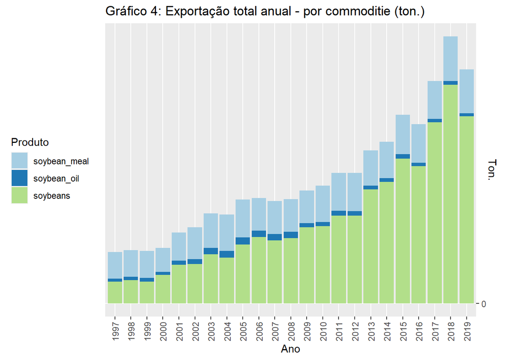

```r
#Construindo um subconjunto com os produtos selecionados
q3 <- subset(data, type == 'Export' & product %in% c('soybeans','soybean_oil','soybean_meal')) %>%
      select(c(date,product, tons)) %>%
      group_by(product , format(as.Date(date), '%Y'))  %>%
      summarise_at('tons', sum, na.rm = F)

# Renomeando as colunas
colnames(q3) <- c('Produto', 'Ano','Ton.')

graf_4 <- ggplot(data = q3 , aes(x = Ano, y = Ton., fill = Produto)) + geom_bar(stat = 'identity', na.rm = T) +
      labs(title = "Gráfico 4: Exportação total anual - por commoditie (ton.)") +
      scale_fill_brewer(palette = "Paired") +
      theme(legend.position="left") +
      scale_y_continuous(breaks = seq(0, 100000000000, 10000000000), position = "right" ) +
      theme(axis.text.x = element_text(angle = 90, vjust = 0.5))

graf_4
```

Ao comparar a evolução mensal e anual é interessante pontuar o componente da sazonalidade, que influencia principalmente a `sojão em grão`. Como o `óleo de soja` e o `farelo de soja` passam por um processo de industrial antes de ser exportado, a sua quantidade exportada não é tão afetada pela sazonalidade.